# Kaduna State Poverty Mapping

October 29, 2017

1. Resources
- Main Machine Learning Project page: https://github.com/nealjean/predicting-poverty
- Tools used: Anaconda, Caffe (pre-built), GDAL downloaded
- [WB LSMS data](http://econ.worldbank.org/WBSITE/EXTERNAL/EXTDEC/EXTRESEARCH/EXTLSMS/0,,contentMDK:23512006~pagePK:64168445~piPK:64168309~theSitePK:3358997,00.html) - unzip to data/input/LSMS
- [DHS data](http://dhsprogram.com/data/dataset_admin/download-datasets.cfm) - unzip to data/input/DHS -
- [Download Trained CNN Model](https://www.dropbox.com/s/4cmfgay9gm2fyj6/predicting_poverty_trained.caffemodel?dl=0)
3. Download nightlights data (R)
4. Process DHS and LSMS Survey Data, linking to nightlights data (R)
5. Save Survey Data outputs (Python)
6. Identify LSMS/DHS cluster download locations (Python)
7. Generate Kaduna Grid for sampled points (R)

The sample grid of daytime satellite images for Kaduna is 16233 evenly spaced points, currently not targeted to specific communities. Daytime images are approximately 1km x 1km, 400x400 pixel RGB images (Google maps zoom level 16) centered on each grid point.

8. Download daytime image locations for LSMS/DHS/New prediction points (R)
9. Save lats-lons numpy for new points (Python)
10. Extract Image Features from downloaded daytime satellite images (Python)
11. Scale and Organize Analysis Data (Python)
12. Ridge Regression for Original Points

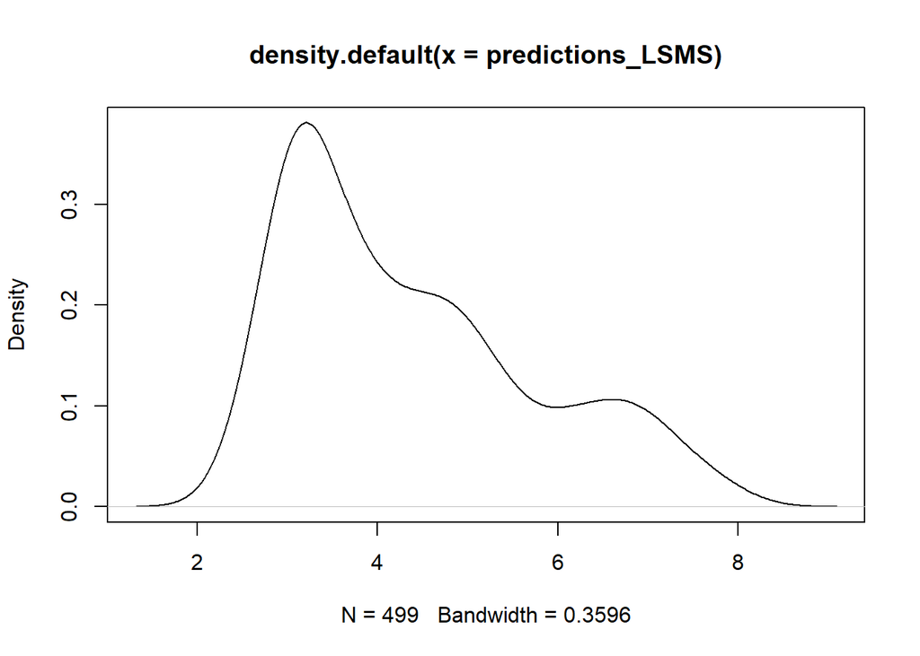

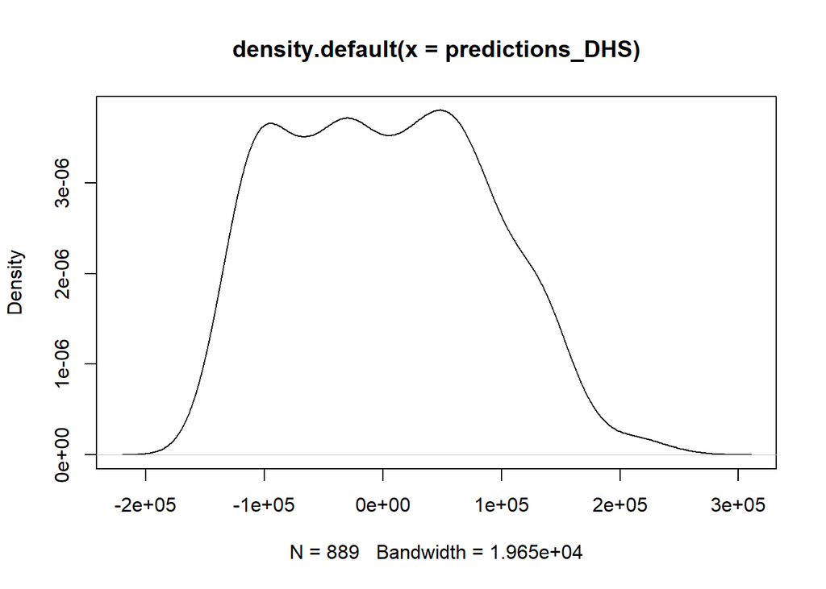

14. Mapping of results for Original Points

Sense-checking the data by predicting back to the LSMS clusters.

[interactive chart not shown]

Sense-checking the data by predicting back to the DHS clusters.

[interactive chart not shown]

15. Ridge Regression for New Predictions

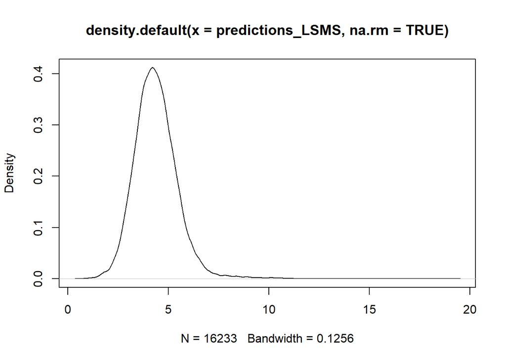

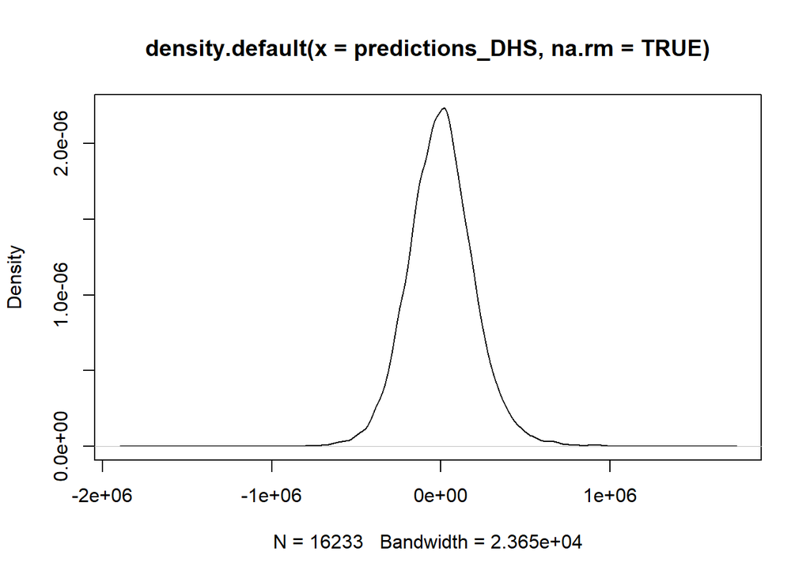

16. Mapping of results for New Predictions

New predictions for Kaduna image locations using LSMS data.

[interactive chart not shown]

New predictions for Kaduna image locations using DHS data.

[interactive chart not shown]

Interpolated predictions for Kaduna image locations using LSMS data (kriging).

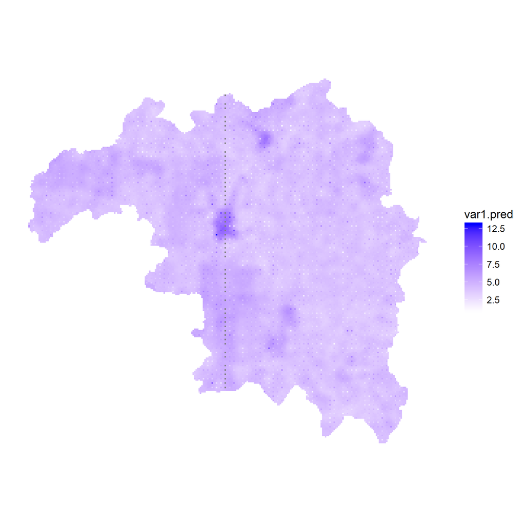

Interpolated (kriging) predictions.